# Obras Paralisadas no Espírito Santo

Guilherme Bride Fernandes

24/03/2021

Esta análise é resultado do Levantamento objeto do Processo TC 707/2020-2 do Tribunal de Contas do Estado do Espírito Santo.

Os documentos do processo podem ser consultados no seguinte endereço:

https://www.tcees.tc.br/consultas/processo/

## Introdução

O levantamento realizado teve por objetivo consolidar as informações referentes ao quantitativo de obras paralisadas, por jurisdicionado e por tipo de obra, os valores por fonte de recurso e os principais motivos das paralisações.

## Resultados

Segundo o Levantamento, existem **290** obras paralisadas no ES, divididas por Microrregião Administrativa conforme a tabela abaixo:

| Microrregião | Obras Paralisadas |
| --- | --- |
| Metropolitana | 94 |
| Litoral Sul | 36 |
| Central Sul | 25 |
| Sudoeste Serrana | 25 |
| Caparaó | 22 |
| Noroeste | 22 |
| Nordeste | 21 |
| Rio Doce | 19 |
| Centro-Oeste | 15 |
| Central Serrana | 11 |

E a mesma quantidade, desta vez por Unidade Gestora (mostrando as 10 primeiras ocorrências):

| Unidade Gestora | Obras Paralisadas | Valor total (mi R$) |
| --- | --- | --- |
| DEPARTAMENTO DE ESTRADAS E RODAGEM DO ESPÍRITO SANTO | 22 | $326.78 |
| PREFEITURA MUNICIPAL DE CARIACICA | 19 | $56.35 |
| PREFEITURA MUNICIPAL DE VITÓRIA | 14 | $93.06 |
| SECRETARIA DE ESTADO DA AGRICULTURA, ABASTECIMENTO, AQUICULTURA E PESCA | 14 | $57.79 |
| INSTITUTO DE OBRAS PÚBLICAS DO ESPÍRITO SANTO | 11 | $326.37 |
| PREFEITURA MUNICIPAL DE CACHOEIRO DE ITAPEMIRIM | 11 | $12.50 |
| PREFEITURA MUNICIPAL DE ITAPEMIRIM | 10 | $37.12 |
| PREFEITURA MUNICIPAL DE ALEGRE | 9 | $1.80 |
| COMPANHIA ESPÍRITO SANTENSE DE SANEAMENTO | 7 | $68.04 |
| PREFEITURA MUNICIPAL DE ANCHIETA | 7 | $7.84 |

## Visualização dos dados

Essas obras dividem-se no território capixaba segundo o seguinte mapa:

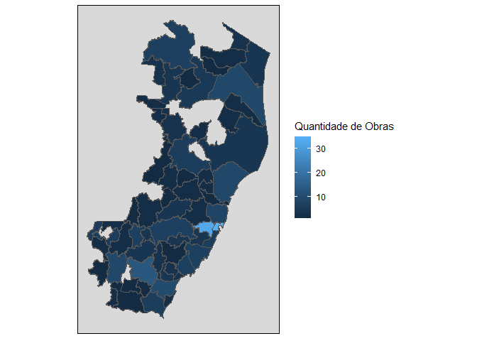

Obras paralisadas por município

## Motivos

O levantamento questionou também os motivos para a paralisação das obras. Os principais motivos apontados pelos respondentes foram os seguintes:

| Motivo | Obras Paralisadas |
| --- | --- |
| ABANDONO DA OBRA PELA CONTRATADA | 39 |
| QUESTÕES TÉCNICAS QUE VIERAM A SER CONHECIDAS SOMENTE APÓS A LICITAÇÃO | 36 |
| CONTINGENCIAMENTO DE RECURSOS PRÓPRIOS | 31 |
| DIFICULDADE DE EXECUÇÃO CONFORME PREVISTO EM PROJETO | 25 |
| INCAPACIDADE FINANCEIRA DA CONTRATADA | 20 |
| AGUARDANDO TRÂMITE INTERNO DE ADITIVO | 18 |
| ATRASO NO REPASSE DE RECURSOS | 18 |
| PROJETO BÁSICO DEFICIENTE | 18 |
| INCAPACIDADE TÉCNICA DA CONTRATADA | 15 |
| ALTERAÇÕES CONTRATUAIS COM REFLEXOS NO LIMITE DO PERCENTUAL DE ADITIVOS | 10 |

No gráfico a seguir é possível verificar as expressões mais frequentes nos motivos apontados.

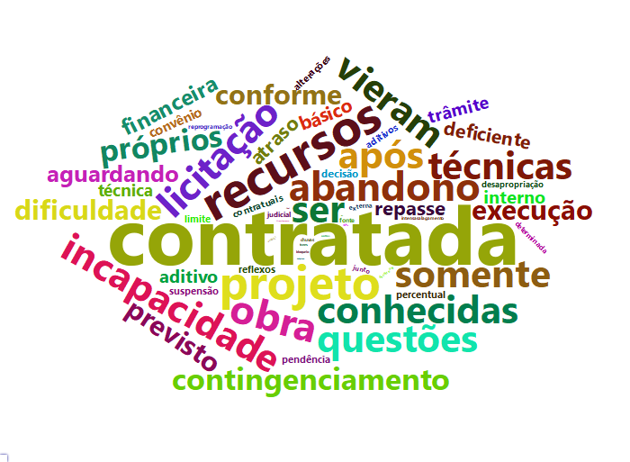

Mapa de Palavras - Motivos

Ou seja, grande parte das paralisações de obras devem-se a problemas com as **Contratadas**. Por outro lado, é responsabilidade da Contratante a correta escolha das Contratadas, bem como a punição em caso de inadimplemento contratual.